# NOAA Storm Analysis

# 1 Synopsis

Storms and other severe weather events can cause both public health and economic problems for communities and municipalities. Many severe events can result in fatalities, injuries, and property damage, and preventing such outcomes to the extent possible is a key concern. This report involves exploring the U.S. National Oceanic and Atmospheric Administration’s (NOAA) storm database and performs a simple, exploratory analysis on it, the result of which addresses the two following questions:

1. Across the United States, which types of events are most harmful with respect to population health?
2. Across the United States, which types of events have the greatest economic consequences?

# 2 System Info and Libraries

```r
library(R.utils)
library(readr)
library(dplyr)
library(reshape2)
library(ggplot2)
library(grid)
library(gridExtra)
```

# 3 Data Preparation

The data for this report come from the U.S. National Oceanic and Atmospheric Administration’s (NOAA) storm database. This database tracks characteristics of major storms and weather events in the United States, including when and where they occur, as well as estimates of any fatalities, injuries, and property damage. The events in the database start in the year 1950 and end in November 2011. Documentation of the database is available as follows:

- National Weather Service [Storm Data Documentation](https://d396qusza40orc.cloudfront.net/repdata%2Fpeer2_doc%2Fpd01016005curr.pdf)
- National Climatic Data Center Storm Events [FAQ](https://d396qusza40orc.cloudfront.net/repdata%2Fpeer2_doc%2FNCDC%20Storm%20Events-FAQ%20Page.pdf)

## 3.1 Data Retrieval

The data come in the form of a comma-separated-value file compressed via the bzip2 algorithm to reduce its size. First, we download the data from the link that was provided for us, unzip it and as a first step in our exploratory analysis view the data.

```r
## Downloading Compressed Raw Data
url <- "https://d396qusza40orc.cloudfront.net/repdata%2Fdata%2FStormData.csv.bz2"
file <- "NOAAStormData.csv"
destfile.csv <- paste("./data/", file, sep = "")
destfile.bz2 <- paste(destfile.csv, ".bz2", sep = "")

if(!file.exists(destfile.bz2)){
  download.file(url, destfile.bz2)
}

## Unzipping the bz2 file and loading Raw Data
if(!file.exists(destfile.csv)){
  bunzip2(destfile.bz2, destfile.csv, remove = FALSE)
}
data <- readr::read_csv(destfile.csv, col_names = TRUE, progress = FALSE,
                        col_types = cols(), trim_ws = TRUE)
## Examining the Data
str(data, give.attr = FALSE)
```

```
## Classes 'tbl_df', 'tbl' and 'data.frame':    902297 obs. of  37 variables:
##  $ STATE__   : num  1 1 1 1 1 1 1 1 1 1 ...
##  $ BGN_DATE  : chr  "4/18/1950 0:00:00" "4/18/1950 0:00:00" "2/20/1951 0:00:00" "6/8/1951 0:00:00" ...
##  $ BGN_TIME  : chr  "0130" "0145" "1600" "0900" ...
##  $ TIME_ZONE : chr  "CST" "CST" "CST" "CST" ...
##  $ COUNTY    : num  97 3 57 89 43 77 9 123 125 57 ...
##  $ COUNTYNAME: chr  "MOBILE" "BALDWIN" "FAYETTE" "MADISON" ...
##  $ STATE     : chr  "AL" "AL" "AL" "AL" ...
##  $ EVTYPE    : chr  "TORNADO" "TORNADO" "TORNADO" "TORNADO" ...
##  $ BGN_RANGE : num  0 0 0 0 0 0 0 0 0 0 ...
##  $ BGN_AZI   : chr  NA NA NA NA ...
##  $ BGN_LOCATI: chr  NA NA NA NA ...
##  $ END_DATE  : chr  NA NA NA NA ...
##  $ END_TIME  : chr  NA NA NA NA ...
##  $ COUNTY_END: num  0 0 0 0 0 0 0 0 0 0 ...
```

[output cut: 23 more lines]

We see there are 902297 observations with 37 variables. To perform our analysis on the data we first need to conduct some kind of preprocessing of the data.

## 3.2 Data Preprocessing

After some examination of the variables of interest - that is primarily “Event Types” as well as “Cost of Damages occured on Property and Crop” and also “Number of casualties (injuries and fatalities)”, we performed the necessary preprocessing as follows:

```r
## cleaning labels for EVENT TYPES
data <- data %>% mutate(EVENTTYPE = toupper(EVTYPE)) %>%
  #replace certain characters with space
  mutate(EVENTTYPE = gsub("/|AND|\\\\|&|-", " ", EVENTTYPE)) %>%
  #remove extra spaces
  mutate(EVENTTYPE = gsub("[ ]{2,}| +$", " ", EVENTTYPE))

## cleaning PROPERTY DAMAGES
data <- data %>% mutate(PROPDAMAGE = toupper(PROPDMGEXP)) %>%
  mutate(PROPDAMAGE = as.numeric(dplyr::recode(PROPDAMAGE,
      '0'=1, '1'=10, '2'=100, '3'=1000,
      '4'=1e4, '5'= 1e5, '6'=1e6, '7'=1e7, '8'=1e8,
      'B'=1e9, 'H'= 100, 'K'=1000, 'M'=1e6,
      '-'=0, '?'=0, '+'=0))) %>%
  mutate(PROPDAMAGE = PROPDAMAGE * PROPDMG)

## cleaning CROP DAMAGES
data <- data %>% mutate(CROPDAMAGE = toupper(CROPDMGEXP)) %>%
  mutate(CROPDAMAGE = as.numeric(dplyr::recode(CROPDAMAGE,
      '0'=1, '2'=100,
      'B'=1e9, 'K'=1000, 'M'=1e6,
      '?'=0))) %>%
  mutate(CROPDAMAGE = CROPDAMAGE * CROPDMG)
```

Cleaning labels for “Event Types” was necessary because some were either misspelled, included particular characters, had extra whitespaces before, after or in-between. As for cleaning the “Cost of Damages” part, this was necessary because rather providing decimal values, the costs were coded with abbreviations (eg. “B” for billions, etc.) or indicated by the number of exponents (eg. “2” for 10^2 or 100).

# 4 Data Processing

Because of some inconsistency in the labelling of the event types, we assign those to the 48 defined in the NOAA documentation. We do this as some form of standarization in the labelling of the event types that we would like to have on the data. Please note that not all observations in the data are assigned due to ambivalence (not sure which event type) or minor effect on the end result. If there are two or more event types defined in the data, we assign the data point to the type that was mentioned at first (eg. “Heat/Drought” $\rightarrow$ “Heat”).

```r
## 48 Event Types defined in the NOAA documentation
## (see: 2.1.1 Storm Data Event Table, p.6)
event.types <- toupper(c("Astronomical Low Tide", "Avalanche", "Blizzard",
    "Coastal Flood",     "Cold/Wind Chill", "Debris Flow", "Dense Fog",
    "Dense Smoke", "Drought", "Dust Devil", "Dust Storm", "Excessive Heat",
    "Extreme Cold/Wind Chill", "Flash Flood", "Flood",     "Frost/Freeze",
    "Funnel Cloud", "Freezing Fog", "Hail", "Heat", "Heavy Rain", "Heavy Snow",
    "High Surf", "High Wind", "Hurricane (Typhoon)", "Ice Storm",
    "Lake-Effect Snow", "Lakeshore Flood", "Lightning", "Marine Hail",
    "Marine High Wind", "Marine Strong Wind", "Marine Thunderstorm Wind",
    "Rip Current", "Seiche", "Sleet", "Storm Surge/Tide", "Strong Wind",
    "Thunderstorm Wind", "Tornado", "Tropical Depression", "Tropical Storm",
    "Tsunami", "Volcanic Ash", "Waterspout", "Wildfire", "Winter Storm",
    "Winter Weather"))

## Define Regular Expressions for Assigning Event Types (if there are 2 or more
## types from the 48 above, assign to type that was mentioned at first)
event.regex <- toupper(c("^Astronomical Low Tide", "^Avalanc", "^Blizzard",
    "^Coastal Flood", "^Cold Wind Chill", "^Debris Flow", "^Dense Fog",
    "^Dense Smoke", "^Drought", "^Dust Devil",
    "^Dust Storm|^Duststorm", "^Excessive Heat",
    "^Extreme Cold Wind Chill|^Extreme Cold|^Extreme Wind ?chill",
    "^Flash Flood|^Flood Flash", "^Flood [^Flash]",
    "^Frost Freeze|^Freeze|^Frost", "^Funnel Cloud", "^Freezing Fog",
    "^Hail", "^Heat", "^Heavy Rain", "^Heavy Snow", "^High Surf", "^High Wind",
    "^Hurricane Typhoon|^Typhoon|^Hurricane", "^Ice Storm", "^Lake-Effect Snow",
    "^Lakeshore Flood", "^Lig.*ing$", "^Marine Hail", "^Marine High Wind",
    "^Marine Strong Wind", "^Marine Thunderstorm Wind|^Marine TSTM Wind",
    "^Rip Current", "^Seiche", "^Sleet", "^Storm Surge Tide|^Storm Surge",
    "^Strong Wind", "^Thunderstorm Wind|^TSTM Wind", "^Tornado",
    "^Tropical Depression", "^Tropical Storm", "^Tsunami", "^Volcanic Ash",
    "^Waterspout|^Water Spout", "^Wildfire|^Wild (.*?)Fire(s)?$",
    "^Winter Storm", "^Winter Weather|^Wint(.*?) Mix"))

## Assign rows depending on the 48 event type and select relevant columns
data.clean <- select(data, c("EVTYPE", "EVENTTYPE", "FATALITIES", "INJURIES",
                  "PROPDAMAGE", "CROPDAMAGE"))
for(i in 1:length(event.types)){
  data.clean[grepl(event.regex[i], data$EVENTTYPE), "EVENTTYPE"] <- event.types[i]
}
```

Next we group the data by event types and store for convenience purposes the final results in two seperate variables `casualties.byEventType` and `damages.byEventType`.

```r
## Group by Event Types
data.byEventType <- data.clean %>% group_by(EVENTTYPE)

casualties.byEventType <- data.byEventType %>%
  summarise(OCCURENCES = length(EVENTTYPE),
            FATALITIES = sum(FATALITIES, na.rm=TRUE),
            INJURIES = sum(INJURIES, na.rm=TRUE),
            TOTALCASUALTIES = FATALITIES+INJURIES)

# damages in billions
damages.byEventType <- data.byEventType %>%
  summarise(OCCURENCES = length(EVENTTYPE),
            PROPDAMAGE = sum(PROPDAMAGE/1e9, na.rm=TRUE),
            CROPDAMAGE = sum(CROPDAMAGE/1e9, na.rm=TRUE),
            TOTALDAMAGE = PROPDAMAGE+CROPDAMAGE) %>%
  arrange(desc(TOTALDAMAGE))
```

# 5 Results

**Q1: Across the United States, which types of events are most harmful with respect to population health?**

As for the impact on public health in the form of fatalities and injuries, we have summarized the top ten event types in the tables below. We also included a barplot that visualizes our results.

```r
top.fatalities <- head(arrange(casualties.byEventType, desc(FATALITIES)), 10)
top.fatalities
```

```
## # A tibble: 10 x 5
##                  EVENTTYPE OCCURENCES FATALITIES INJURIES TOTALCASUALTIES
##                      <chr>      <int>      <dbl>    <dbl>           <dbl>
##  1                 TORNADO      60686       5658    91364           97022
##  2          EXCESSIVE HEAT       1679       1903     6525            8428
##  3                    HEAT        848       1118     2494            3612
##  4             FLASH FLOOD      55672       1035     1800            2835
##  5               LIGHTNING      15759        816     5230            6046
##  6       THUNDERSTORM WIND     324677        709     9468           10177
##  7             RIP CURRENT        777        577      529            1106
##  8                   FLOOD      25336        471     6789            7260
##  9 EXTREME COLD/WIND CHILL       1890        304      260             564
## 10               HIGH WIND      21802        293     1471            1764
```

```r
top.injuries <- head(arrange(casualties.byEventType, desc(INJURIES)), 10)
top.injuries
```

```
## # A tibble: 10 x 5
##            EVENTTYPE OCCURENCES FATALITIES INJURIES TOTALCASUALTIES
##                <chr>      <int>      <dbl>    <dbl>           <dbl>
##  1           TORNADO      60686       5658    91364           97022
##  2 THUNDERSTORM WIND     324677        709     9468           10177
##  3             FLOOD      25336        471     6789            7260
##  4    EXCESSIVE HEAT       1679       1903     6525            8428
##  5         LIGHTNING      15759        816     5230            6046
##  6              HEAT        848       1118     2494            3612
##  7         ICE STORM       2008         89     1977            2066
##  8       FLASH FLOOD      55672       1035     1800            2835
##  9          WILDFIRE       4231         90     1606            1696
## 10         HIGH WIND      21802        293     1471            1764
```

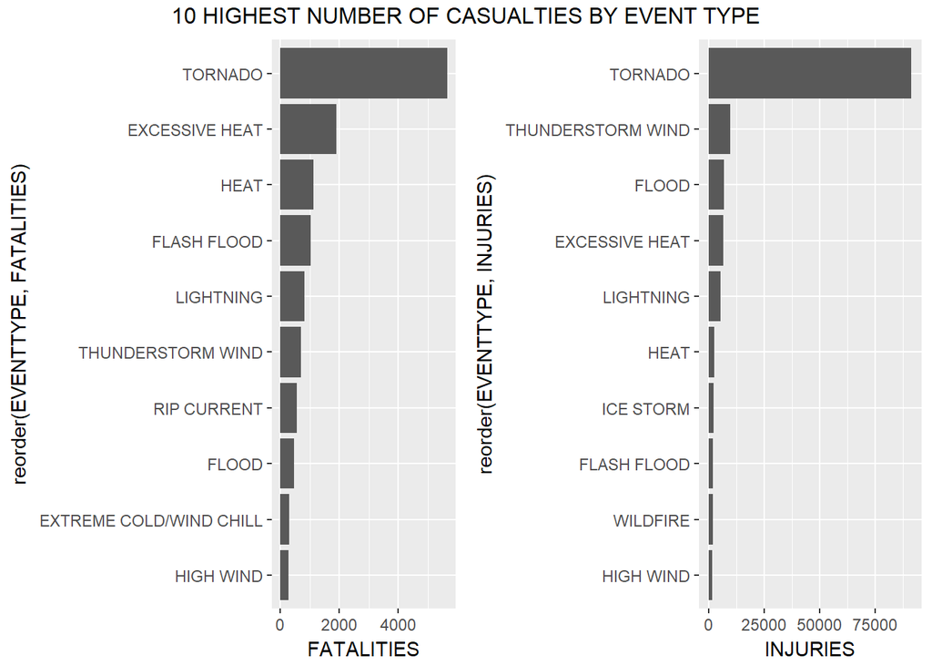

```r
g1 <- ggplot(top.fatalities, aes(reorder(EVENTTYPE,FATALITIES),FATALITIES)) +
    geom_col() + coord_flip()
g2 <- ggplot(top.injuries, aes(reorder(EVENTTYPE,INJURIES),INJURIES)) +
    geom_col() + coord_flip()
grid.arrange(g1, g2, ncol=2,
    top=toupper("10 Highest Number of Casualties By Event Type"))
```

As can be seen, most casualties with respect to fatalities are due to **TORNADOS**, **EXCESSIVE HEAT** and **HEAT**. With respect to injuries most casualties are due to **TORNADOS**, **THUNDERSTORMS** and **FLOODS**, but also **EXCESSIVE HEAT** close to the latter.

**Q2: Across the United States, which types of events have the greatest economic consequences?**

With respect to the impact on the economy the results are summarized and visualized as follow (measured in billions of dollars):

```r
top.damages <- head(damages.byEventType, 10)
top.damages
```

```
## # A tibble: 10 x 5
##              EVENTTYPE OCCURENCES PROPDAMAGE CROPDAMAGE TOTALDAMAGE
##                  <chr>      <int>      <dbl>      <dbl>       <dbl>
##  1               FLOOD      25336 144.658210  5.7747684  150.432978
##  2 HURRICANE (TYPHOON)        299  85.356410  5.5161178   90.872528
##  3             TORNADO      60686  58.552152  0.4174615   58.969613
##  4    STORM SURGE/TIDE        409  47.964724  0.0008550   47.965579
##  5         FLASH FLOOD      55672  17.589812  1.5321972   19.122009
##  6                HAIL     288776  15.977470  3.0260946   19.003565
##  7             DROUGHT       2501   1.046106 13.9725718   15.018678
##  8   THUNDERSTORM WIND     324677   9.969173  1.2243980   11.193571
##  9         RIVER FLOOD        173   5.118945  5.0294590   10.148404
## 10           ICE STORM       2008   3.944928  5.0221135    8.967041
```

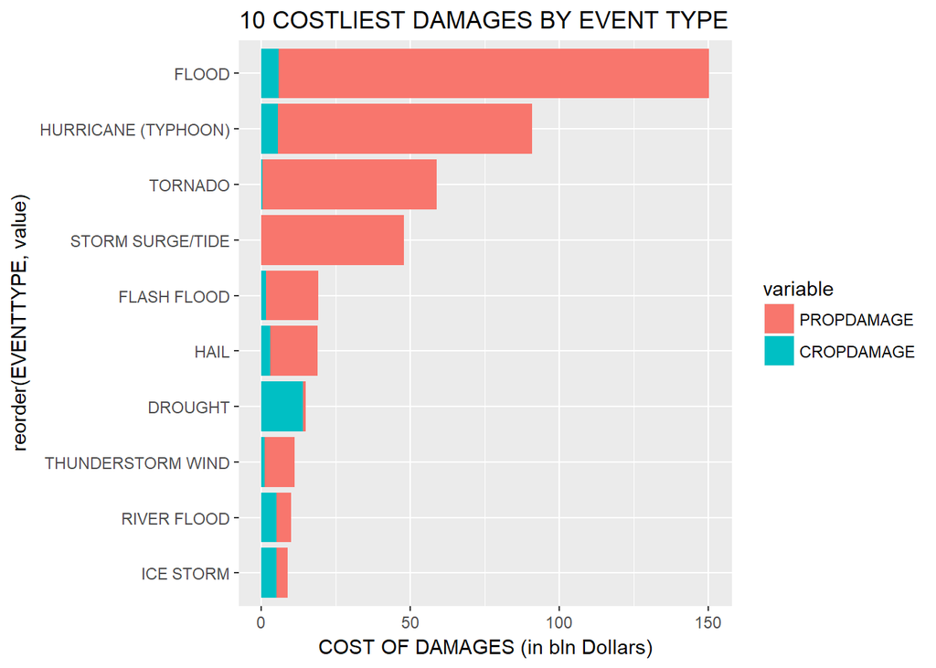

```r
top.damages <- melt(as.data.frame(top.damages[,c(1,3:4)]))
g3 <- ggplot(top.damages, aes(reorder(EVENTTYPE,value), value, fill=variable)) + geom_col() +
    coord_flip() + ylab("COST OF DAMAGES (in bln Dollars)") +
    ggtitle(toupper("10 Costliest Damages By Event Type"))
g3
```

Here **FLOODS**, **HURRICANES/TYPHOONS** and **TORNADOS** have the greatest economic consequences. It should be also noted that damages on crops are the highest due to **DROUGHT**, followed by **FLOODS**.